# Assignment_6_LNM_Proportional_Hazard_LG

```python
import pandas as pd
import matplotlib.pyplot as plt

from lifelines.plotting import plot_lifetimes
from lifelines import KaplanMeierFitter
from lifelines import WeibullAFTFitter
from lifelines import CoxPHFitter
```

We will train a Proportional Hazard model to identify important prognostic factors from the nine explanatory variables. We will use the Backward Selection method to exclude non-significant predictors.

We first include all nine explanatory variables in the model. After we have trained a Proportional Hazard model, we will retrieve the summary object to obtain the test significance values (i.e., the p-value) of the explanatory variables.

Next, we will look among the explanatory variables **whose p-values are more than 0.15**. Then, remove the explanatory variable, if any, that has the highest p-value from the model. We will repeat the Backward steps until there are no more explanatory variables that we can remove.

```python
# Load dataset
df = pd.read_csv('myeloma.csv')

# Define the Cox Proportional Hazards model
cph = CoxPHFitter()

# List of all explanatory variables
variables = ['LogBUN', 'HGB', 'Platelet', 'Age', 'LogWBC', 'Frac', 'LogPBM', 'Protein', 'SCalc']

# Initial fit with all variables
X = df[variables + ['Time', 'VStatus']]
cph.fit(X, duration_col='Time', event_col='VStatus')

# Initialize a list to store the step summary
steps_summary = []

# Backward selection process
while True:
    # Get the summary of the current model
    summary = cph.summary

    # Filter variables with p-value greater than 0.15
    non_significant = summary[summary['p'] > 0.15]

    if not non_significant.empty:
        # Find the variable with the highest p-value
        variable_to_remove = non_significant['p'].idxmax()
        highest_p_value = non_significant['p'].max()

        # Add step information to summary
        steps_summary.append({'Variable Removed': variable_to_remove, 'P-Value': highest_p_value})

        # Remove the variable with the highest p-value
        variables.remove(variable_to_remove)

        # Refit the model without the removed variable
        X = df[variables + ['Time', 'VStatus']]
        cph.fit(X, duration_col='Time', event_col='VStatus')
    else:
        # If there are no variables to remove, break the loop
        break

# Convert steps summary to a DataFrame for easy viewing
steps_summary_df = pd.DataFrame(steps_summary)

# Print the step summary table
print(steps_summary_df)

print("-------------------------------------------------------------")

# Print the final model's summary
print(cph.summary)
```

```
  Variable Removed   P-Value
0           LogWBC  0.621011
1          Protein  0.693410
2         Platelet  0.656020
3           LogPBM  0.452029
4             Frac  0.426168
5              Age  0.180759
6            SCalc  0.173778
-------------------------------------------------------------
               coef  exp(coef)  se(coef)  coef lower 95%  coef upper 95%  \
covariate
LogBUN     1.715977   5.562106  0.618553        0.503635        2.928319
HGB       -0.119663   0.887219  0.057422       -0.232209       -0.007117

           exp(coef) lower 95%  exp(coef) upper 95%  cmp to         z  \
covariate
LogBUN                1.654725            18.696171     0.0  2.774178
HGB                   0.792781             0.992908     0.0 -2.083907

                  p  -log2(p)
covariate
LogBUN     0.005534  7.497426
HGB        0.037169  4.749769
```

### (a) Please provide a Step Summary table. The table will show the explanatory variable removed from each step and the variable’s test significance value.

```python
print(steps_summary_df)
```

```
  Variable Removed   P-Value
0           LogWBC  0.621011
1          Protein  0.693410
2         Platelet  0.656020
3           LogPBM  0.452029
4             Frac  0.426168
5              Age  0.180759
6            SCalc  0.173778
```

### (b) Please provide a table that shows the explanatory variables included in the final model. Besides, show these statistics: parameter estimates, standard errors, p-values, Hazard Ratios, and 95% confidence interval for the Hazard Ratios.

```python
# Final model summary
final_summary = cph.summary

# Extracting relevant information for the final table
final_table = final_summary[['coef', 'se(coef)', 'p', 'exp(coef)', 'exp(coef) lower 95%', 'exp(coef) upper 95%']]
final_table = final_table.rename(columns={'coef': 'Parameter Estimates',
                                          'se(coef)': 'Standard Errors',
                                          'p': 'P-Values',
                                          'exp(coef)': 'Hazard Ratios',
                                          'exp(coef) lower 95%': '95% CI Lower Bound for HR',
                                          'exp(coef) upper 95%': '95% CI Upper Bound for HR'})

# Print the final table
print(final_table)
```

```
           Parameter Estimates  Standard Errors  P-Values  Hazard Ratios  \
covariate
LogBUN                1.715977         0.618553  0.005534       5.562106
HGB                  -0.119663         0.057422  0.037169       0.887219

           95% CI Lower Bound for HR  95% CI Upper Bound for HR
covariate
LogBUN                      1.654725                  18.696171
HGB                         0.792781                   0.992908
```

### (c) Please plot the baseline hazard for the final model. What is the chance that individuals will experience an event at time 40 given they survive up to 40? (you can use a rough projection on y axis)

### An indication of how likely the event is to occur at that moment for someone who has not yet experienced the event.

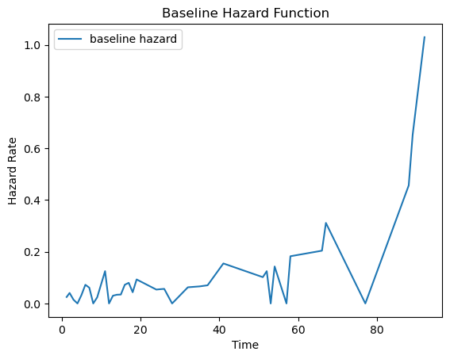

```python
# Plot the baseline hazard function
cph.baseline_hazard_.plot()
plt.title('Baseline Hazard Function')
plt.xlabel('Time')
plt.ylabel('Hazard Rate')
plt.show()
```

```python
cph.baseline_hazard_
```

|  | baseline hazard |
| --- | --- |
| 1.25 | 0.024871 |
| 2.00 | 0.040638 |
| 3.00 | 0.014423 |
| 4.00 | 0.000000 |
| 5.00 | 0.032157 |
| 6.00 | 0.072276 |
| 7.00 | 0.061062 |
| 8.00 | 0.000000 |
| 9.00 | 0.023692 |
| 11.00 | 0.125110 |
| 12.00 | 0.000000 |
| 13.00 | 0.030122 |
| 14.00 | 0.033795 |
| 15.00 | 0.034489 |
| 16.00 | 0.072387 |
| 17.00 | 0.079825 |
| 18.00 | 0.043416 |
| 19.00 | 0.092953 |
| 24.00 | 0.053724 |
| 25.00 | 0.055221 |
| 26.00 | 0.056442 |
| 28.00 | 0.000000 |
| 32.00 | 0.062597 |
| 35.00 | 0.066091 |
| 37.00 | 0.070314 |
| 41.00 | 0.154793 |
| 51.00 | 0.101785 |
| 52.00 | 0.124965 |
| 53.00 | 0.000000 |
| 54.00 | 0.143125 |
| 57.00 | 0.000000 |
| 58.00 | 0.182639 |
| 66.00 | 0.204123 |
| 67.00 | 0.311528 |
| 77.00 | 0.000000 |
| 88.00 | 0.456535 |
| 89.00 | 0.652242 |
| 92.00 | 1.029920 |

### The chance is around 0.15

### (d) Please plot LogBUN partial effects with the values=[0,0.5,1,1.5,2]. Remember, with this exercise, we examine what will the survival curve look like as we vary a single covariate while holding everything else equal.

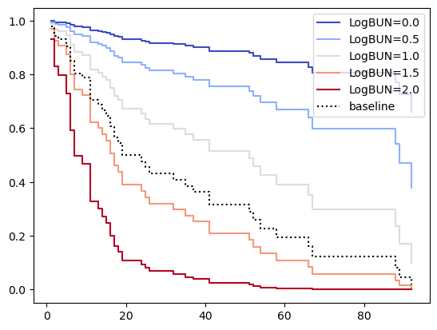

```python
cph.plot_partial_effects_on_outcome(covariates='LogBUN', values=[0,0.5,1,1.5,2], cmap='coolwarm')
```

#### How will the result look like if I fit the model with all covariates? - Looks same

```python
cphall = CoxPHFitter()
cphall.fit(df, duration_col='Time', event_col='VStatus')
cphall.print_summary()
```

| model | lifelines.CoxPHFitter |
| --- | --- |
| duration col | 'Time' |
| event col | 'VStatus' |
| baseline estimation | breslow |
| number of observations | 65 |
| number of events observed | 48 |
| partial log-likelihood | -145.39 |
| time fit was run | 2024-02-23 07:03:23 UTC |

|  | coef | exp(coef) | se(coef) | coef lower 95% | coef upper 95% | exp(coef) lower 95% | exp(coef) upper 95% | cmp to | z | p | -log2(p) |
| --- | --- | --- | --- | --- | --- | --- | --- | --- | --- | --- | --- |
| LogBUN | 1.86 | 6.40 | 0.66 | 0.57 | 3.14 | 1.77 | 23.15 | 0.00 | 2.83 | <0.005 | 7.74 |
| HGB | -0.13 | 0.88 | 0.07 | -0.27 | 0.02 | 0.77 | 1.02 | 0.00 | -1.75 | 0.08 | 3.64 |
| Platelet | -0.25 | 0.78 | 0.51 | -1.26 | 0.75 | 0.28 | 2.11 | 0.00 | -0.50 | 0.62 | 0.69 |
| Age | -0.01 | 0.99 | 0.02 | -0.05 | 0.03 | 0.95 | 1.03 | 0.00 | -0.67 | 0.50 | 0.99 |
| LogWBC | 0.35 | 1.42 | 0.72 | -1.05 | 1.76 | 0.35 | 5.79 | 0.00 | 0.49 | 0.62 | 0.69 |
| Frac | 0.34 | 1.41 | 0.41 | -0.46 | 1.14 | 0.63 | 3.13 | 0.00 | 0.84 | 0.40 | 1.32 |
| LogPBM | 0.38 | 1.46 | 0.49 | -0.57 | 1.34 | 0.56 | 3.81 | 0.00 | 0.78 | 0.43 | 1.21 |
| Protein | 0.01 | 1.01 | 0.03 | -0.04 | 0.06 | 0.96 | 1.07 | 0.00 | 0.50 | 0.62 | 0.69 |
| SCalc | 0.13 | 1.14 | 0.11 | -0.08 | 0.34 | 0.93 | 1.40 | 0.00 | 1.24 | 0.22 | 2.21 |

| Concordance | 0.68 |
| --- | --- |
| Partial AIC | 308.77 |
| log-likelihood ratio test | 17.62 on 9 df |
| -log2(p) of ll-ratio test | 4.65 |

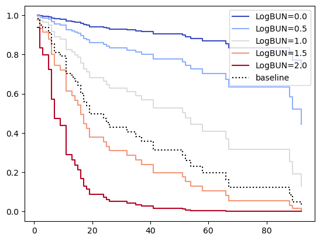

```python
cphall.plot_partial_effects_on_outcome(covariates='LogBUN', values=[0,0.5,1,1.5,2], cmap='coolwarm')
```